# Geriatric_Data

```python
q4_data = [122,7,51,39,21,0,9,1,5]
q4_cat = ['Primary Care', 'Mental Care', 'Dental Care', 'Foot Care', 'Womens Health', 'Sexual Health', 'Care Coordination', 'Help with Insurance', 'Wellness & Nutrition']
```

```
<BarContainer object of 8 artists>
```

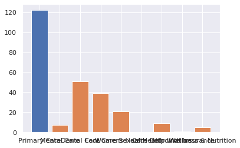

```python
import seaborn as sns
import matplotlib.pyplot as plt
sns.set()

plt.bar(q4_cat, q4_data)
plt.bar(q4_cat[1:], q4_data[1:])
```

```
[Text(0, 0.5, 'Prevalence'), Text(0.5, 0, 'Service')]
```

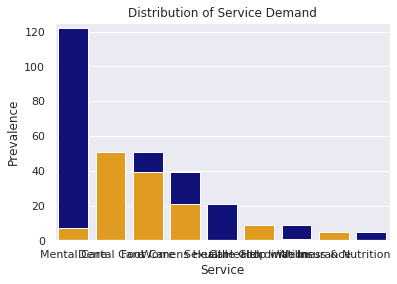

```python
a = sns.barplot(x = q4_cat, y = q4_data, color = 'darkblue')
sns.barplot(x = q4_cat[1:], y = q4_data[1:], color = 'orange')

a.set(title = 'Distribution of Service Demand')
a.set(xlim=(-.5,8.5))

a.set(ylim=(0,125))
a.set(xlabel='Service', ylabel='Prevalence')
```

```python
q4_perc = [x / sum(q4_data) for x in q4_data]
q4_perc
```

```
[0.47843137254901963,
 0.027450980392156862,
 0.2,
 0.15294117647058825,
 0.08235294117647059,
 0.0,
 0.03529411764705882,
 0.00392156862745098,
 0.0196078431372549]
```

```python
a = sns.barplot(x = q4_cat, y = q4_perc_0, color = 'orange')
sns.barplot(x = q4_cat, y = q4_perc, color = 'darkblue')




a.set(title = 'Distribution of Service Demand')
a.set(xlim=(-.5,8.5))

a.set(ylim=(0,.5))
a.set(xlabel='Service', ylabel='Demand')
a.set_xticklabels(a.get_xticklabels(), rotation=45, horizontalalignment='right')
```

[output not shown]

```python
import numpy as np
barWidth = 0.4
r1 = np.arange(len(q4_data))
r2 = [x + barWidth for x in r1]

q4_data_0 = [0,7,51,39,21,0,9,1,5]

plt.bar(r1, q4_data, color='#9f0d5f', width=barWidth, edgecolor='white', label='var1')
plt.bar(r2, q4_data_0, color='#557f2d', width=barWidth, edgecolor='white', label='var2')
```

```python
q4_perc_0 = [x / sum(q4_data_0) for x in q4_data_0]
q4_perc_0
```

```python
plt.bar(r1, q4_perc, color='#9f0d5f', width=barWidth, edgecolor='white', label='var1')
plt.bar(r2, q4_perc_0, color='#589f2d', width=barWidth, edgecolor='white', label='var2')
```

```python
a = sns.barplot(x = q4_cat, y = q4_perc_0, color = 'orange')





a.set(title = 'Distribution of Service Demand Except Primary Care')
a.set(xlim=(-.5,8.5))

a.set(ylim=(0,.4))
a.set(xlabel='Service', ylabel='Demand')
a.set_xticklabels(a.get_xticklabels(), rotation=45, horizontalalignment='right')
```

```python
a = sns.barplot(x = q4_cat, y = q4_perc, color = 'darkblue')
a.set(title = 'Distribution of Service Demand')
a.set(xlim=(-.5,8.5))

a.set(ylim=(0,.5))
a.set(xlabel='Service', ylabel='Demand')
a.set_xticklabels(a.get_xticklabels(), rotation=45, horizontalalignment='right')
```

```python
a = sns.barplot(x = q4_cat, y = q4_perc_0, color = 'orange')
sns.barplot(x = q4_cat, y = q4_perc, color = 'darkblue')

a.set(title = 'Distribution of Service Demand')
a.set(xlim=(-.5,8.5))

a.set(ylim=(0,.5))
a.set(xlabel='Service', ylabel='Demand')
a.set_xticklabels(a.get_xticklabels(), rotation=45, horizontalalignment='right')
```

[output not shown]

# q2

```python
q2_data = [17, 4, 8, 21, 74]
q2_perc = [13.71, 3.23, 6.45, 16.94, 59.68]
q2_cat = ['<6', '6-12', '12-36', '36-60', '>60']
```

```python
a = sns.barplot(x = q2_cat, y = q2_perc, color = 'orange')
#sns.barplot(x = q4_cat, y = q4_perc, color = 'darkblue')

a.set(title = 'Length of Time with Provider (months)')
a.set(xlim=(-.5,4.5))


a.set(xlabel='Time (Months)', ylabel='Response (Percent)')
a.set_xticklabels(a.get_xticklabels(), rotation=45, horizontalalignment='right')
```

### Remove greater than 5 years

```python
q2_data_0 = [17, 4, 8, 21]
q2_perc_0 = [13.71, 3.23, 6.45, 16.94]
q2_cat = ['<6', '6-12', '12-36', '36-60', '>60']
q2_cat_0 = ['<6', '6-12', '12-36', '36-60']
```

```
[Text(0, 0, '<6'),
```

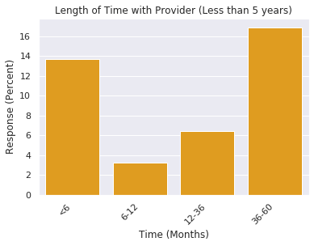

```python
a = sns.barplot(x = q2_cat_0, y = q2_perc_0, color = 'orange')
#sns.barplot(x = q4_cat, y = q4_perc, color = 'darkblue')

a.set(title = 'Length of Time with Provider (Less than 5 years)')
a.set(xlim=(-.5,3.5))


a.set(xlabel='Time (Months)', ylabel='Response (Percent)')
a.set_xticklabels(a.get_xticklabels(), rotation=45, horizontalalignment='right')
```

### we can see that other than established doctor-patient relationships of over 5 years, there is an interesting distribution of new relationships and considerably established ones. Several explanations are possible, including mobility/relocation, changes to insurance, etc. The intermediate figures could be transitions from these changes towards a long term relationship, but could just as easily be related to other changes

### Note: cross-validate versus satisfaction with provider

# q3

```python
q3_data_raw =[5,19,13,26,8,49,4]
extrap = 49/5
q3_data = [5,19,13,26,8,extrap, extrap, extrap, extrap, extrap,4]
q3_cat = [0,1,2,3,4,5,6,7,8,9,10]
perc_extrap = 39.52/5
q3_perc = [4.03,15.32,10.48,20.97,6.45,perc_extrap,perc_extrap,perc_extrap,perc_extrap,perc_extrap,3.23]
```

```
[Text(0, 0, '0'),
```

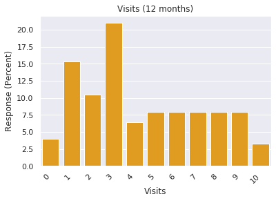

```python
a = sns.barplot(x = q3_cat, y = q3_perc, color = 'orange')
#sns.barplot(x = q4_cat, y = q4_perc, color = 'darkblue')

a.set(title = 'Visits (12 months)')



a.set(xlabel='Visits', ylabel='Response (Percent)')
a.set_xticklabels(a.get_xticklabels(), rotation=45, horizontalalignment='right')
```

### extrapolating over a simple average, the category [5-9] shows nothing over particular interest, though it appears that 3 visits per year appears to be the most common

### by re-binning, we can assess even further

```python
q3_cat_re = ['0-1','2-3','4-5','6-7','8-9','10 or more']
q3_data_re = [24,39,17.8,19.6,19.6,4]
q3_perc_re = [x/124 for x in q3_data_re]
```

```
[Text(0, 0, '0-1'),
```

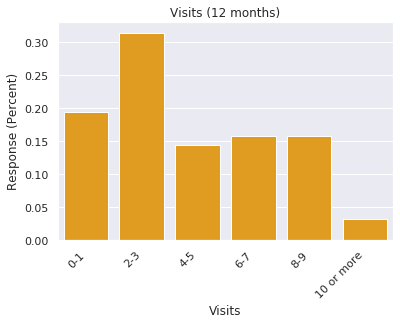

```python
a = sns.barplot(x = q3_cat_re, y = q3_perc_re, color = 'orange')
a.set(title = 'Visits (12 months)')



a.set(xlabel='Visits', ylabel='Response (Percent)')
a.set_xticklabels(a.get_xticklabels(), rotation=45, horizontalalignment='right')
```

### since the original data binned in a group of 5, the most robust way to compare is simply to combine the first 5 categories into one, and only assess 3 groups. This is horribly lacking in granularity, but will be more certain

```python
q3_data_robust = [71,49,4]
q3_perc_robust = [x/124 for x in q3_data_robust]
q3_cat_robust = ['0-4','5-9','10+']
```

```
approximately 57% of respondents visited their provider 0-4 times in the past year
```

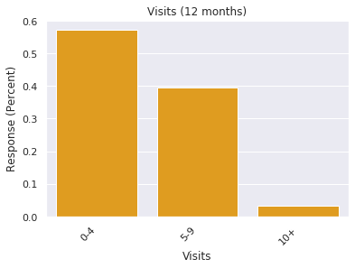

```python
a = sns.barplot(x = q3_cat_robust, y = q3_perc_robust, color = 'orange')
a.set(title = 'Visits (12 months)')



a.set(xlabel='Visits', ylabel='Response (Percent)')
a.set_xticklabels(a.get_xticklabels(), rotation=45, horizontalalignment='right')
print('approximately ' + str(int(q3_perc_robust[0]*100))+ '% of respondents visited their provider 0-4 times in the past year')
```

### the only certainty is that over 57% of those polled make fewer than 5 visit per year, which is the dominant majority

# Interest in the Sample Population - variation from the norm

```python
race_cat = ['hispanic', 'black', 'asian', 'white']
race_perc = [56.56, 20.49, 13.93, 9.84]
marital_cat = ['single', 'married', 'separated', 'divorced', 'widowed']
marital_perc = [21.95, 22.76, 12.20, 15.45, 27.64]
education_cat = ['Less than high school','High school or equivalent','Some college',
'Associates Degree/Technical Degree/Vocational School','Bachelors Degree','Masters Degree','Graduate Certificate', 'Doctoral Degree']
education_perc = [43.44, 30.33, 12.30, 8.2, 2.46, 2.46, 0.82,0]
gender_cat = ['male', 'female']
gender_perc = [44.72, 55.28]
```

### for simplicity, and very little bias, assume all survey participants are 65 years old

### education by race data 2017

#### https://www.equityinhighered.org/indicators/u-s-population-trends-and-educational-attainment/educational-attainment-by-race-and-ethnicity/

```python
education_nat = [10.4, 28.8, 16.3, 10.3, 21.3, 9.5, 1.5, 1.9]
education_hispanic = [29.5, 31, 14.4, 8, 12.2, 3.9, .5, 7]
education_black = [11.9, 33, 20.4, 10.3, 15.3, 7.1, .7, 1.1]
education_asian = [9.1, 19.9, 9.3, 6.4, 30.7, 17.9, 2.1, 4.7]
education_white = [5.9, 28.3, 16.6, 11.2, 23.7, 10.5, 1.8, 2]
```

```python
#ignoring gender differences in the short run for (again) immediate simplicity
```

```python
import pandas as pd
df = pd.DataFrame(columns = [education_cat])
df
```

|  | Less than high school | High school or equivalent | Some college | Associates Degree/Technical Degree/Vocational School | Bachelors Degree | Masters Degree | Graduate Certificate | Doctoral Degree |
| --- | --- | --- | --- | --- | --- | --- | --- | --- |

```python
df.loc[0] = education_nat
df.loc[1] = education_perc
df.loc[2] = education_hispanic
df.loc[3] = education_black
df.loc[4] = education_asian
df.loc[5] = education_white
df
```

|  | Less than high school | High school or equivalent | Some college | Associates Degree/Technical Degree/Vocational School | Bachelors Degree | Masters Degree | Graduate Certificate | Doctoral Degree |
| --- | --- | --- | --- | --- | --- | --- | --- | --- |
| 0 | 10.40 | 28.80 | 16.3 | 10.3 | 21.30 | 9.50 | 1.50 | 1.9 |
| 1 | 43.44 | 30.33 | 12.3 | 8.2 | 2.46 | 2.46 | 0.82 | 0.0 |
| 2 | 29.50 | 31.00 | 14.4 | 8.0 | 12.20 | 3.90 | 0.50 | 7.0 |
| 3 | 11.90 | 33.00 | 20.4 | 10.3 | 15.30 | 7.10 | 0.70 | 1.1 |
| 4 | 9.10 | 19.90 | 9.3 | 6.4 | 30.70 | 17.90 | 2.10 | 4.7 |
| 5 | 5.90 | 28.30 | 16.6 | 11.2 | 23.70 | 10.50 | 1.80 | 2.0 |

```python
df.loc[6] = [x*race_perc[0]/100 for x in education_nat] #hispanic expectation
df.loc[7] = [x*race_perc[1]/100 for x in education_nat] #black expectation
df.loc[8] = [x*race_perc[2]/100 for x in education_nat] #asian expectation
df.loc[9] = [x*race_perc[3]/100 for x in education_nat] #white expectation
```

```python
df
```

|  | Less than high school | High school or equivalent | Some college | Associates Degree/Technical Degree/Vocational School | Bachelors Degree | Masters Degree | Graduate Certificate | Doctoral Degree |
| --- | --- | --- | --- | --- | --- | --- | --- | --- |
| 0 | 10.40000 | 28.80000 | 16.30000 | 10.30000 | 21.30000 | 9.50000 | 1.50000 | 1.90000 |
| 1 | 43.44000 | 30.33000 | 12.30000 | 8.20000 | 2.46000 | 2.46000 | 0.82000 | 0.00000 |
| 2 | 29.50000 | 31.00000 | 14.40000 | 8.00000 | 12.20000 | 3.90000 | 0.50000 | 7.00000 |
| 3 | 11.90000 | 33.00000 | 20.40000 | 10.30000 | 15.30000 | 7.10000 | 0.70000 | 1.10000 |
| 4 | 9.10000 | 19.90000 | 9.30000 | 6.40000 | 30.70000 | 17.90000 | 2.10000 | 4.70000 |
| 5 | 5.90000 | 28.30000 | 16.60000 | 11.20000 | 23.70000 | 10.50000 | 1.80000 | 2.00000 |
| 6 | 5.88224 | 16.28928 | 9.21928 | 5.82568 | 12.04728 | 5.37320 | 0.84840 | 1.07464 |
| 7 | 2.13096 | 5.90112 | 3.33987 | 2.11047 | 4.36437 | 1.94655 | 0.30735 | 0.38931 |
| 8 | 1.44872 | 4.01184 | 2.27059 | 1.43479 | 2.96709 | 1.32335 | 0.20895 | 0.26467 |
| 9 | 1.02336 | 2.83392 | 1.60392 | 1.01352 | 2.09592 | 0.93480 | 0.14760 | 0.18696 |

```
[Text(0, 0, 'Less than high school'),
```

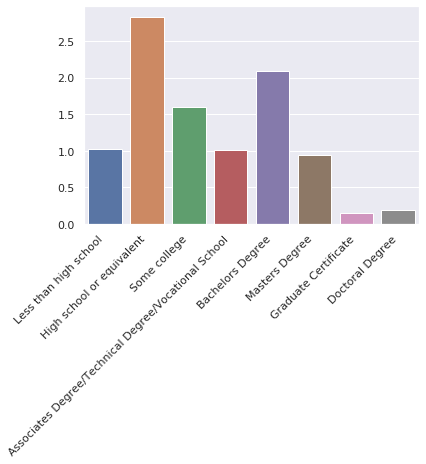

```python
a = sns.barplot(x= education_cat, y= [x*race_perc[3]/100 for x in education_nat]) # white expectation
a.set_xticklabels(a.get_xticklabels(), rotation=45, horizontalalignment='right')
```

```
[Text(0, 0, 'Less than high school'),
```

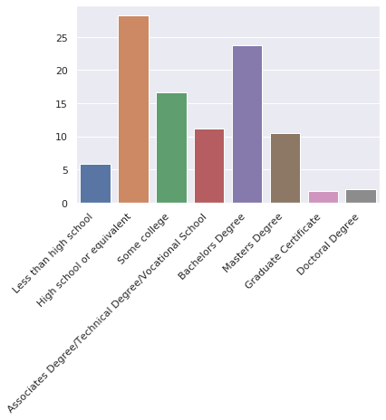

```python
a = sns.barplot(x= education_cat, y= education_white)
a.set_xticklabels(a.get_xticklabels(), rotation=45, horizontalalignment='right')
```

### comparing the shape is most important. it shows the difference in expectation vs outcome for the sample in educational attainment, an established corrolary to income